# Pierson Method

Pierson Wodarz

7/29/2020

```r
library(readr)
library(faraway)
house_data = read_csv("kc_house_data.csv")
house_data = house_data[ ,-c(1, 2, 10)] # remove id and date from data frame as these are not relevant and view (since someone looking to buy a house may not have the information of number of views on a home)

# Coerce factor variables to be factors
house_data$yr_renovated = ifelse(house_data$yr_renovated == 0, 0, 1) #change yr_rennovated to boolean data type
house_data$yr_renovated = as.factor(house_data$yr_renovated)
house_data$waterfront = as.factor(house_data$waterfront)
house_data$zipcode = as.factor(house_data$zipcode)

set.seed(19940627)
house_idx = sample(nrow(house_data), as.integer(nrow(house_data) * 0.80))
house_trn = house_data[house_idx, ]
house_tst = house_data[-house_idx, ]
```

We write a function that will return various selection metrics to be used as we progress through our model building.

```r
sel_crit = function(model, data) {
  n = nrow(data)
  LOOCV_RMSE = sqrt(mean((resid(model) / (1 - hatvalues(model))) ^ 2))
  RMSE =  sqrt((1 / n) * sum((predict(model, newdata = data) - data$price) ^ 2))
  adjR2 = summary(model)$adj.r.squared
  AIC = extractAIC(model)[2]
  num_p = length(coef(model)) - 1
  data.frame(LOOCV_RMSE = LOOCV_RMSE, RMSE = RMSE, adjR2 = adjR2, AIC = AIC, num_p = num_p)
}
```

We observe each variables’ relationship to price to orient ourselves and additionally view the correlation between variables (mostly between price and the predictor, but in some cases between predictors).

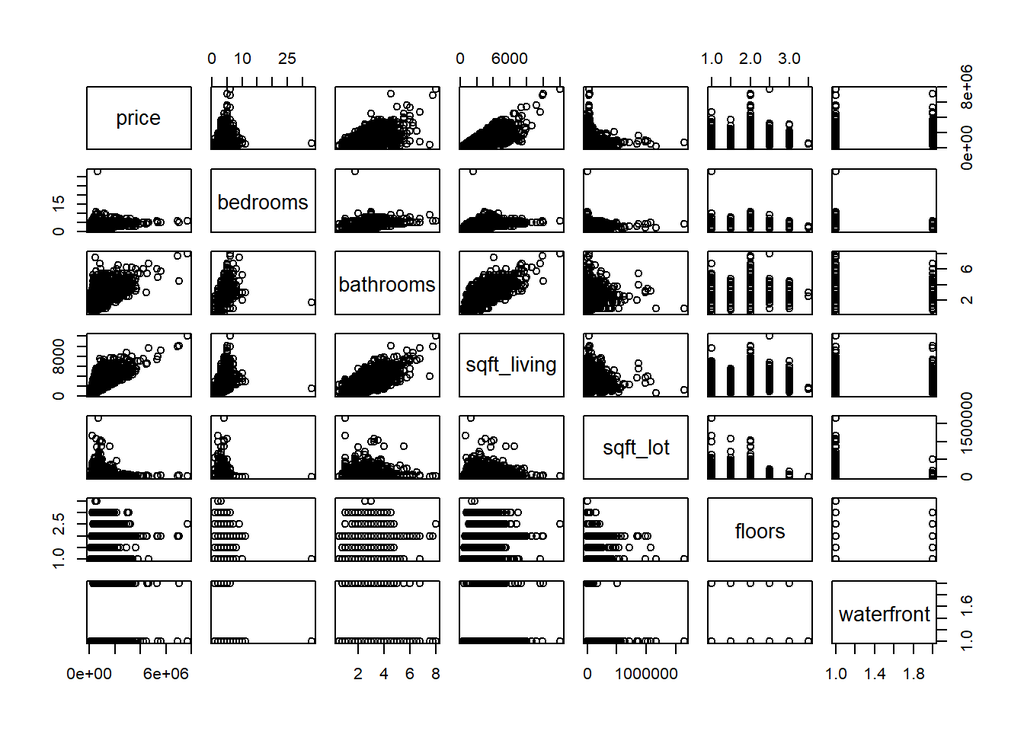

```r
pairs(house_trn[, 1:7])
```

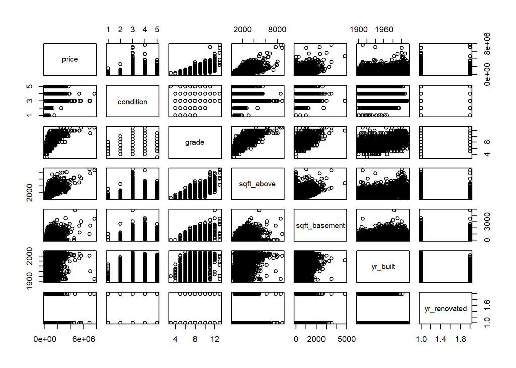

```r
pairs(house_trn[ , c(1,8:13)])
```

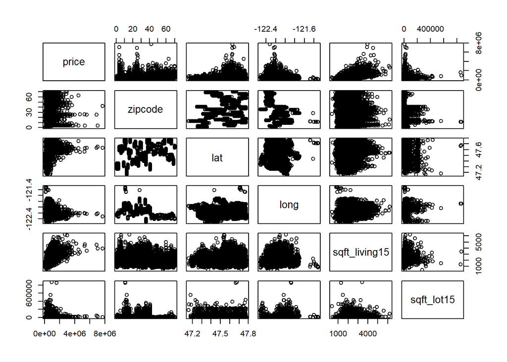

```r
pairs(house_trn[ , c(1,14:18)])
```

```r
cor(house_trn[, -c(7, 13, 14)]) > 0.7
```

```
##               price bedrooms bathrooms sqft_living sqft_lot floors condition
## price          TRUE    FALSE     FALSE        TRUE    FALSE  FALSE     FALSE
## bedrooms      FALSE     TRUE     FALSE       FALSE    FALSE  FALSE     FALSE
## bathrooms     FALSE    FALSE      TRUE        TRUE    FALSE  FALSE     FALSE
## sqft_living    TRUE    FALSE      TRUE        TRUE    FALSE  FALSE     FALSE
## sqft_lot      FALSE    FALSE     FALSE       FALSE     TRUE  FALSE     FALSE
## floors        FALSE    FALSE     FALSE       FALSE    FALSE   TRUE     FALSE
## condition     FALSE    FALSE     FALSE       FALSE    FALSE  FALSE      TRUE
## grade         FALSE    FALSE     FALSE        TRUE    FALSE  FALSE     FALSE
## sqft_above    FALSE    FALSE     FALSE        TRUE    FALSE  FALSE     FALSE
## sqft_basement FALSE    FALSE     FALSE       FALSE    FALSE  FALSE     FALSE
## yr_built      FALSE    FALSE     FALSE       FALSE    FALSE  FALSE     FALSE
## lat           FALSE    FALSE     FALSE       FALSE    FALSE  FALSE     FALSE
## long          FALSE    FALSE     FALSE       FALSE    FALSE  FALSE     FALSE
## sqft_living15 FALSE    FALSE     FALSE        TRUE    FALSE  FALSE     FALSE
## sqft_lot15    FALSE    FALSE     FALSE       FALSE     TRUE  FALSE     FALSE
##               grade sqft_above sqft_basement yr_built   lat  long sqft_living15
## price         FALSE      FALSE         FALSE    FALSE FALSE FALSE         FALSE
## bedrooms      FALSE      FALSE         FALSE    FALSE FALSE FALSE         FALSE
## bathrooms     FALSE      FALSE         FALSE    FALSE FALSE FALSE         FALSE
## sqft_living    TRUE       TRUE         FALSE    FALSE FALSE FALSE          TRUE
## sqft_lot      FALSE      FALSE         FALSE    FALSE FALSE FALSE         FALSE
## floors        FALSE      FALSE         FALSE    FALSE FALSE FALSE         FALSE
## condition     FALSE      FALSE         FALSE    FALSE FALSE FALSE         FALSE
## grade          TRUE       TRUE         FALSE    FALSE FALSE FALSE          TRUE
## sqft_above     TRUE       TRUE         FALSE    FALSE FALSE FALSE          TRUE
## sqft_basement FALSE      FALSE          TRUE    FALSE FALSE FALSE         FALSE
## yr_built      FALSE      FALSE         FALSE     TRUE FALSE FALSE         FALSE
## lat           FALSE      FALSE         FALSE    FALSE  TRUE FALSE         FALSE
## long          FALSE      FALSE         FALSE    FALSE FALSE  TRUE         FALSE
## sqft_living15  TRUE       TRUE         FALSE    FALSE FALSE FALSE          TRUE
## sqft_lot15    FALSE      FALSE         FALSE    FALSE FALSE FALSE         FALSE
##               sqft_lot15
## price              FALSE
## bedrooms           FALSE
## bathrooms          FALSE
## sqft_living        FALSE
## sqft_lot            TRUE
## floors             FALSE
## condition          FALSE
## grade              FALSE
## sqft_above         FALSE
## sqft_basement      FALSE
## yr_built           FALSE
## lat                FALSE
## long               FALSE
## sqft_living15      FALSE
## sqft_lot15          TRUE
```

First, we create an additive model to provide ourselves a baseline from which to improve. Additionally, we perform backwards AIC selection to reduce the number of predictors.

```r
add_mod = lm(price ~ ., data = house_trn)
sel_crit(add_mod, house_tst)
```

```
##   LOOCV_RMSE   RMSE  adjR2    AIC num_p
## 1     167980 157148 0.7959 415585    85
```

```r
add_mod_aic = step(add_mod, direction = "backward", trace = 0)
sel_crit(add_mod_aic, house_tst)
```

```
##   LOOCV_RMSE   RMSE  adjR2    AIC num_p
## 1     167980 157148 0.7959 415585    84
```

We note that backwards AIC selection reduced our model by a single predictor, and was not particularly useful. But we established a *baseline* RMSE of 1.571510^{5}.

Next, we try an interactive model.

```r
int_mod = lm(price ~ (.) * (.), data = house_trn)
sel_crit(int_mod, house_tst)
```

```
##   LOOCV_RMSE   RMSE adjR2    AIC num_p
## 1        Inf 114894 0.919 400679  1309
```

This model has a much lower RMSE (1.148910^{5}) compared to the additive model. However, the number of parameters is very high.

We note that most of these parameters are from (properly) treating zipcode as a factor. So we investigate what happens if we remove zipcode as an interaction parameter (but still have zipcode as a predictor).

```r
int_mod_no_zip = lm(price ~ (. -zipcode) * (. -zipcode) + zipcode, data = house_trn)
sel_crit((int_mod_no_zip), house_tst)
```

```
##   LOOCV_RMSE   RMSE  adjR2    AIC num_p
## 1     133697 130145 0.8776 406856   205
```

Try some 3-way interactions

```r
int_mod = lm(price ~ (. -zipcode ) * (. -zipcode ) * (. -zipcode ) + zipcode, data = house_trn)
sel_crit(int_mod, house_tst)
```

```
##   LOOCV_RMSE   RMSE  adjR2    AIC num_p
## 1     177994 154730 0.9015 403571   765
```

Three-way appears to be a dead-end (at least without zipcode - we simply don’t have the computing power to include zipcode in a 3-way interaction as the number of predictors would be too high)

We add in some polynomial terms with observations from our pairs graphs

```r
poly_mod = lm(price ~ (. -zipcode) * (. -zipcode) + zipcode + I(lat ^ 2) + I(1 / long) + I(bedrooms ^ 2) + I(bathrooms ^ 2) + I(sqft_living ^ 2) + I(1 / sqft_lot) + I(grade ^ 2) + log(condition) + I(sqft_above ^ 2), data = house_trn)
sel_crit((poly_mod), house_tst)
```

```
##   LOOCV_RMSE   RMSE  adjR2    AIC num_p
## 1     132738 129820 0.8794 406603   214
```

Trying to remove some unnecessary parameters, take a look at correlation

```r
round(cor(house_trn[, -c(7,13,14)]),2)
```

```
##               price bedrooms bathrooms sqft_living sqft_lot floors condition
## price          1.00     0.31      0.53        0.70     0.08   0.25      0.04
## bedrooms       0.31     1.00      0.51        0.57     0.03   0.17      0.03
## bathrooms      0.53     0.51      1.00        0.75     0.08   0.50     -0.13
## sqft_living    0.70     0.57      0.75        1.00     0.16   0.34     -0.06
## sqft_lot       0.08     0.03      0.08        0.16     1.00  -0.01     -0.01
## floors         0.25     0.17      0.50        0.34    -0.01   1.00     -0.27
## condition      0.04     0.03     -0.13       -0.06    -0.01  -0.27      1.00
## grade          0.66     0.35      0.67        0.76     0.10   0.45     -0.15
## sqft_above     0.60     0.47      0.69        0.88     0.17   0.52     -0.16
## sqft_basement  0.33     0.30      0.28        0.44     0.01  -0.25      0.17
## yr_built       0.05     0.15      0.50        0.31     0.04   0.49     -0.36
## lat            0.30    -0.01      0.02        0.04    -0.09   0.05     -0.02
## long           0.02     0.13      0.22        0.24     0.22   0.13     -0.11
## sqft_living15  0.58     0.39      0.57        0.76     0.13   0.28     -0.09
## sqft_lot15     0.07     0.03      0.08        0.18     0.71  -0.01      0.00
##               grade sqft_above sqft_basement yr_built   lat  long sqft_living15
## price          0.66       0.60          0.33     0.05  0.30  0.02          0.58
## bedrooms       0.35       0.47          0.30     0.15 -0.01  0.13          0.39
## bathrooms      0.67       0.69          0.28     0.50  0.02  0.22          0.57
## sqft_living    0.76       0.88          0.44     0.31  0.04  0.24          0.76
## sqft_lot       0.10       0.17          0.01     0.04 -0.09  0.22          0.13
## floors         0.45       0.52         -0.25     0.49  0.05  0.13          0.28
## condition     -0.15      -0.16          0.17    -0.36 -0.02 -0.11         -0.09
## grade          1.00       0.75          0.17     0.45  0.11  0.20          0.71
## sqft_above     0.75       1.00         -0.05     0.42 -0.01  0.34          0.73
## sqft_basement  0.17      -0.05          1.00    -0.13  0.11 -0.14          0.20
## yr_built       0.45       0.42         -0.13     1.00 -0.15  0.41          0.32
## lat            0.11      -0.01          0.11    -0.15  1.00 -0.13          0.04
## long           0.20       0.34         -0.14     0.41 -0.13  1.00          0.34
## sqft_living15  0.71       0.73          0.20     0.32  0.04  0.34          1.00
## sqft_lot15     0.11       0.19          0.02     0.06 -0.09  0.25          0.17
##               sqft_lot15
## price               0.07
## bedrooms            0.03
## bathrooms           0.08
## sqft_living         0.18
## sqft_lot            0.71
## floors             -0.01
## condition           0.00
## grade               0.11
## sqft_above          0.19
## sqft_basement       0.02
## yr_built            0.06
## lat                -0.09
## long                0.25
## sqft_living15       0.17
## sqft_lot15          1.00
```

```r
poly_mod = lm(price ~ (. -zipcode - sqft_above  -sqft_lot15) * (. -zipcode - sqft_above  -sqft_lot15) + zipcode + I(lat ^ 2) + I(1 / long) + I(bedrooms ^ 2) + I(bathrooms ^ 2) + I(sqft_living ^ 2) + I(1 / sqft_lot) + log(condition), data = house_trn)
sel_crit((poly_mod), house_tst)
```

```
##   LOOCV_RMSE   RMSE  adjR2    AIC num_p
## 1     133016 129529 0.8784 406741   181
```

Trying to remove some other stuff

```r
poly_mod = lm(price ~ (. -zipcode - sqft_above  -sqft_lot15) * (. -zipcode - sqft_above  -sqft_lot15) + zipcode + I(lat ^ 2) +  I(bedrooms ^ 2)  , data = house_trn)
sel_crit((poly_mod), house_tst)
```

```
##   LOOCV_RMSE   RMSE  adjR2    AIC num_p
## 1     134080 129105 0.8766 406981   176
```

What if we just tried a poly and interaction model:

```r
poly_int_mod = lm(price ~ (. -zipcode - sqft_above  -sqft_lot15) * (. -zipcode - sqft_above  -sqft_lot15) + zipcode + ((. -zipcode -sqft_above  -sqft_lot15)^2),  data = house_trn)
sel_crit((poly_int_mod), house_tst)
```

```
##   LOOCV_RMSE   RMSE  adjR2    AIC num_p
## 1     134238 129397 0.8762 407032   174
```

We see that there isn’t much value in most polynomial terms so we remove those. Try adding an exponent for the bedrooms as it appears to have a gaussian peak.

```r
poly_mod = lm(price ~ (. -zipcode - sqft_above  -sqft_lot15) * (. -zipcode - sqft_above  -sqft_lot15) + zipcode + I(lat ^ 2) +  I(bedrooms ^ 2)  + exp(bedrooms), data = house_trn)
sel_crit((poly_mod), house_tst)
```

```
##   LOOCV_RMSE   RMSE  adjR2    AIC num_p
## 1   11348487 129098 0.8766 406983   177
```

```r
poly_mod = lm(price ~ (. -zipcode - sqft_above  -sqft_lot15) * (. -zipcode - sqft_above  -sqft_lot15) + zipcode + I(lat ^ 2) +  I(bedrooms ^ 2)  + exp(bedrooms) + I(sqft_lot ^ -1), data = house_trn)
sel_crit((poly_mod), house_tst)
```

```
##   LOOCV_RMSE   RMSE adjR2    AIC num_p
## 1    7470931 128803 0.878 406786   178
```

```r
poly_mod = lm(price ~ (. -zipcode - sqft_above  -sqft_lot15 ) * (. -zipcode - sqft_above  -sqft_lot15 ) + zipcode + I(lat ^ 2) +  I(bedrooms ^ 2)  + exp(bedrooms) + I(sqft_lot ^ -1) + exp(condition), data = house_trn)
sel_crit((poly_mod), house_tst)
```

```
##   LOOCV_RMSE   RMSE adjR2    AIC num_p
## 1    7460432 128801 0.878 406787   179
```

```r
poly_mod_aic = step(poly_mod, direction = "backward", trace = 0)
sel_crit(poly_mod_aic, house_tst)
```

```
##   LOOCV_RMSE   RMSE  adjR2    AIC num_p
## 1     132396 128671 0.8781 406743   147
```

```r
summary(poly_mod)
```

```
##
## Call:
## lm(formula = price ~ (. - zipcode - sqft_above - sqft_lot15) *
##     (. - zipcode - sqft_above - sqft_lot15) + zipcode + I(lat^2) +
##     I(bedrooms^2) + exp(bedrooms) + I(sqft_lot^-1) + exp(condition),
##     data = house_trn)
##
## Residuals:
##      Min       1Q   Median       3Q      Max
## -1536168   -52322     -790    47220  1875620
##
## Coefficients:
##                              Estimate Std. Error t value Pr(>|t|)
## (Intercept)                 -5.86e+09   1.34e+09   -4.37  1.2e-05 ***
## bedrooms                     5.78e+06   1.78e+06    3.26  0.00113 **
## bathrooms                   -1.01e+07   2.81e+06   -3.58  0.00034 ***
## sqft_living                 -2.52e+04   3.02e+03   -8.35  < 2e-16 ***
## sqft_lot                     4.51e+01   2.41e+01    1.87  0.06110 .
## floors                       7.39e+06   3.02e+06    2.44  0.01451 *
## waterfront1                  8.11e+07   1.94e+07    4.18  2.9e-05 ***
## condition                    5.75e+05   2.18e+06    0.26  0.79184
## grade                       -1.73e+07   1.73e+06  -10.00  < 2e-16 ***
## sqft_basement                1.02e+04   3.93e+03    2.60  0.00923 **
## yr_built                     7.22e+05   6.38e+04   11.32  < 2e-16 ***
## yr_renovated1                2.79e+07   6.04e+06    4.62  3.8e-06 ***
## lat                          1.68e+08   3.19e+07    5.28  1.3e-07 ***
## long                        -1.99e+07   1.04e+07   -1.90  0.05698 .
## sqft_living15               -1.08e+04   2.95e+03   -3.66  0.00025 ***
## zipcode98002                 2.34e+04   1.37e+04    1.70  0.08845 .
## zipcode98003                -2.15e+04   1.20e+04   -1.79  0.07397 .
## zipcode98004                 6.59e+05   2.36e+04   27.95  < 2e-16 ***
## zipcode98005                 2.45e+05   2.49e+04    9.86  < 2e-16 ***
## zipcode98006                 2.27e+05   2.16e+04   10.50  < 2e-16 ***
## zipcode98007                 2.22e+05   2.57e+04    8.63  < 2e-16 ***
## zipcode98008                 2.57e+05   2.45e+04   10.47  < 2e-16 ***
## zipcode98010                 1.53e+05   2.57e+04    5.95  2.7e-09 ***
## zipcode98011                 1.17e+05   3.01e+04    3.90  9.8e-05 ***
## zipcode98014                 1.28e+05   3.27e+04    3.91  9.3e-05 ***
## zipcode98019                 1.19e+05   3.18e+04    3.74  0.00018 ***
## zipcode98022                 1.97e+05   2.85e+04    6.91  5.0e-12 ***
```

[output cut: 144 more lines]

```
## yr_built:lat                -2.22e+02   5.37e+02   -0.41  0.67906
## yr_built:long                5.79e+03   5.10e+02   11.35  < 2e-16 ***
## yr_built:sqft_living15      -5.63e-01   1.25e-01   -4.49  7.2e-06 ***
## yr_renovated1:lat           -8.62e+04   4.75e+04   -1.81  0.06975 .
## yr_renovated1:long           1.82e+05   4.75e+04    3.82  0.00013 ***
## yr_renovated1:sqft_living15  3.85e+01   1.17e+01    3.30  0.00095 ***
## lat:long                     1.95e+05   2.17e+05    0.90  0.36955
## lat:sqft_living15            5.96e+01   2.12e+01    2.81  0.00493 **
## long:sqft_living15          -7.36e+01   2.21e+01   -3.33  0.00086 ***
## ---
## Signif. codes:  0 '***' 0.001 '**' 0.01 '*' 0.05 '.' 0.1 ' ' 1
##
## Residual standard error: 129000 on 17097 degrees of freedom
## Multiple R-squared:  0.879,  Adjusted R-squared:  0.878
## F-statistic:  696 on 179 and 17097 DF,  p-value: <2e-16
```